# dpa_result_part

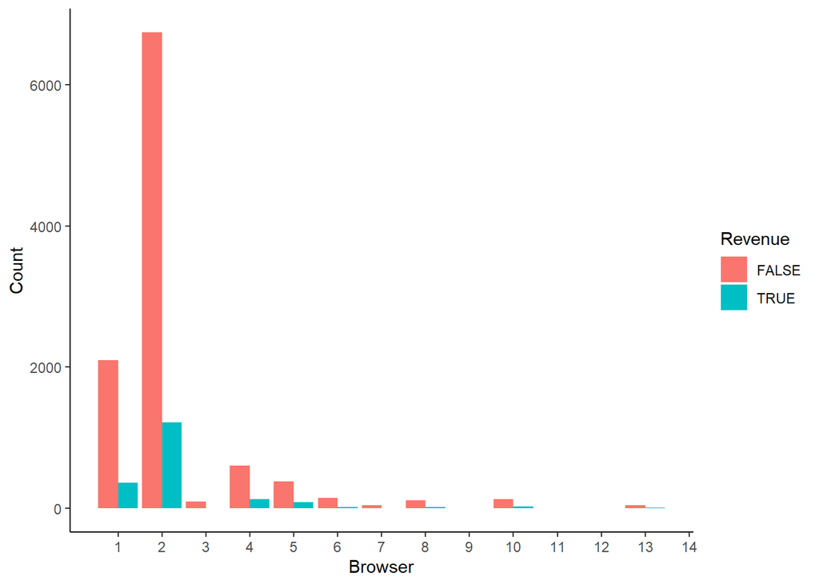

```r
plot1 <- ggplot(data, aes(x = Browser, fill = Revenue)) +
         geom_bar(position = "dodge") +
         labs(x = "Browser", y = "Count", fill = "Revenue") +
         scale_x_continuous(breaks = 1:15) +
         theme_classic()

plot1
```

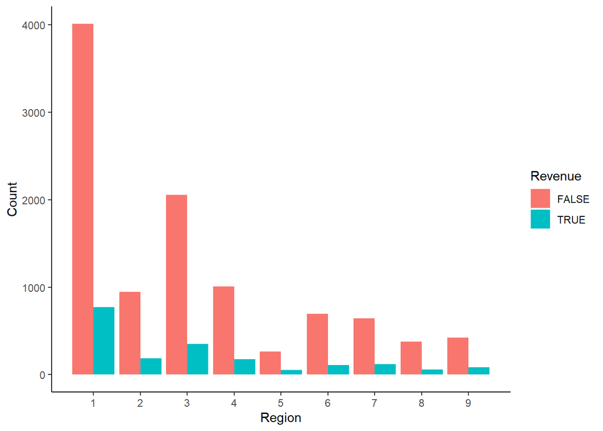

```r
plot1 <- ggplot(data, aes(x = Region, fill = Revenue)) +
         geom_bar(position = "dodge") +
         labs(x = "Region", y = "Count", fill = "Revenue") +
         scale_x_continuous(breaks = 1:11) +
         theme_classic()

plot1
```

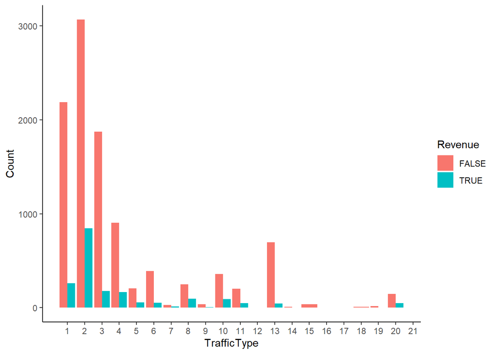

```r
plot1 <- ggplot(data, aes(x = TrafficType, fill = Revenue)) +
         geom_bar(position = "dodge") +
         labs(x = "TrafficType", y = "Count", fill = "Revenue") +
         scale_x_continuous(breaks = 1:22) +
         theme_classic()

plot1
```

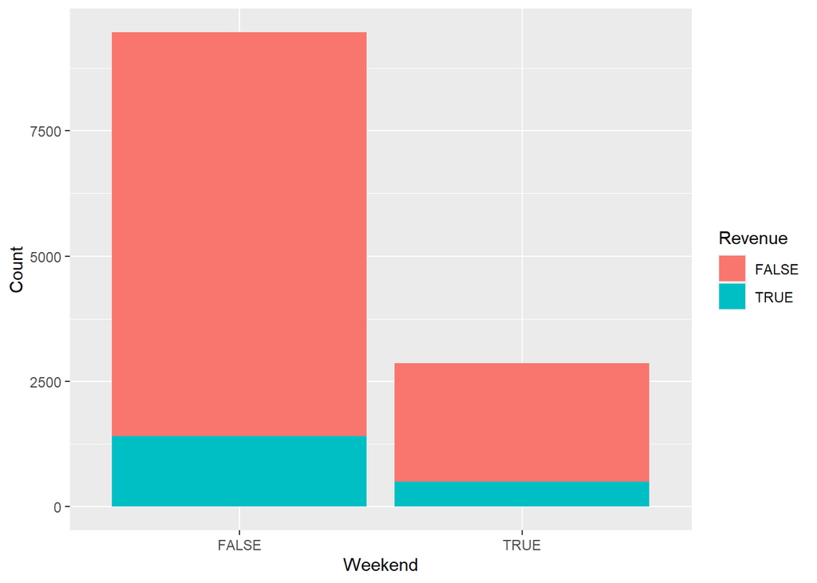

```r
plot1 <- ggplot(data.frame(data), aes(Weekend, fill=Revenue)) + geom_bar() + labs(x = "Weekend") + labs(y = "Count")
plot1
```

```r
table(data$Weekend, data$Revenue)
```

```
##
##         FALSE TRUE
##   FALSE  8053 1409
##   TRUE   2369  499
```

```r
cat("\nData shows that revenue on non weekend is almost thrice that of revenue on weekend")
```

```
##
## Data shows that revenue on non weekend is almost thrice that of revenue on weekend
```

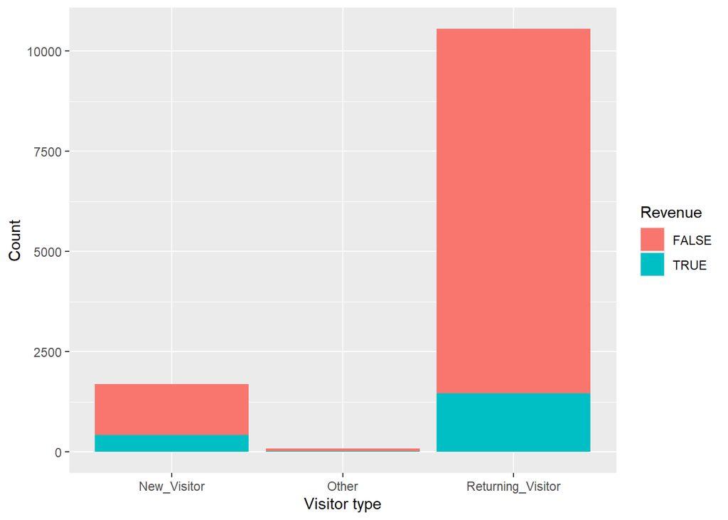

```r
plot1 <- ggplot(data.frame(data), aes(VisitorType, fill=Revenue)) + geom_bar() + labs(x = "Visitor type") + labs(y = "Count")
plot1
```

```r
table(data$VisitorType, data$Revenue)
```

```
##
##                     FALSE TRUE
##   New_Visitor        1272  422
##   Other                69   16
##   Returning_Visitor  9081 1470
```

```r
cat("\nData shows that revenue from returning visitor is approximately 3.5 times as that of new visitor")
```

```
##
## Data shows that revenue from returning visitor is approximately 3.5 times as that of new visitor
```

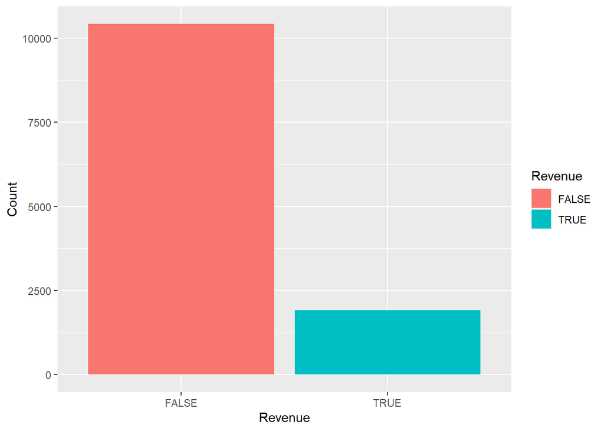

```r
plot1 <- ggplot(data.frame(data), aes(Revenue, fill=Revenue)) + geom_bar() + labs(x = "Revenue") + labs(y = "Count")
plot1
```

```r
table(data$Revenue)
```

```
##
## FALSE  TRUE
## 10422  1908
```

```r
cat("\nData shows that there are more data to explain non revenue tahn revenue. That is there are approximately 5.5 times more data explaining non revenue that revenue.")
```

```
##
## Data shows that there are more data to explain non revenue tahn revenue. That is there are approximately 5.5 times more data explaining non revenue that revenue.
```

```r
head(data)
```

```
##   Administrative Administrative_Duration Informational Informational_Duration
## 1              0                       0             0                      0
## 2              0                       0             0                      0
## 3              0                       0             0                      0
## 4              0                       0             0                      0
## 5              0                       0             0                      0
## 6              0                       0             0                      0
##   ProductRelated ProductRelated_Duration BounceRates ExitRates PageValues
## 1              1                0.000000  0.20000000 0.2000000          0
## 2              2               64.000000  0.00000000 0.1000000          0
## 3              1                0.000000  0.20000000 0.2000000          0
## 4              2                2.666667  0.05000000 0.1400000          0
## 5             10              627.500000  0.02000000 0.0500000          0
## 6             19              154.216667  0.01578947 0.0245614          0
##   SpecialDay Month OperatingSystems Browser Region TrafficType
## 1          0   Feb                1       1      1           1
## 2          0   Feb                2       2      1           2
## 3          0   Feb                4       1      9           3
## 4          0   Feb                3       2      2           4
## 5          0   Feb                3       3      1           4
## 6          0   Feb                2       2      1           3
##         VisitorType Weekend Revenue
## 1 Returning_Visitor   FALSE   FALSE
## 2 Returning_Visitor   FALSE   FALSE
## 3 Returning_Visitor   FALSE   FALSE
## 4 Returning_Visitor   FALSE   FALSE
## 5 Returning_Visitor    TRUE   FALSE
## 6 Returning_Visitor   FALSE   FALSE
```

Transforming categorical attribute to factor data type so as to do one hot encoding. Weekend and Revenue are not integers hence converting them to integers before converting them factor.

```r
data <- data %>%
  mutate(OperatingSystems = as.factor(OperatingSystems),
         Browser = as.factor(Browser),
         Region = as.factor(Region),
         TrafficType = as.factor(TrafficType),
         VisitorType = as.factor(VisitorType),
         Weekend = as.integer(Weekend),
         Revenue = as.integer(Revenue)
         )
```

```r
head(data)
```

```
##   Administrative Administrative_Duration Informational Informational_Duration
## 1              0                       0             0                      0
## 2              0                       0             0                      0
## 3              0                       0             0                      0
## 4              0                       0             0                      0
## 5              0                       0             0                      0
## 6              0                       0             0                      0
##   ProductRelated ProductRelated_Duration BounceRates ExitRates PageValues
## 1              1                0.000000  0.20000000 0.2000000          0
## 2              2               64.000000  0.00000000 0.1000000          0
## 3              1                0.000000  0.20000000 0.2000000          0
## 4              2                2.666667  0.05000000 0.1400000          0
## 5             10              627.500000  0.02000000 0.0500000          0
## 6             19              154.216667  0.01578947 0.0245614          0
##   SpecialDay Month OperatingSystems Browser Region TrafficType
## 1          0   Feb                1       1      1           1
## 2          0   Feb                2       2      1           2
## 3          0   Feb                4       1      9           3
## 4          0   Feb                3       2      2           4
## 5          0   Feb                3       3      1           4
## 6          0   Feb                2       2      1           3
##         VisitorType Weekend Revenue
## 1 Returning_Visitor       0       0
## 2 Returning_Visitor       0       0
## 3 Returning_Visitor       0       0
## 4 Returning_Visitor       0       0
## 5 Returning_Visitor       1       0
## 6 Returning_Visitor       0       0
```

```r
data_v2 <- data
data_v2$Revenue <- as.factor(data_v2$Revenue)
head(data_v2)
```

```
##   Administrative Administrative_Duration Informational Informational_Duration
## 1              0                       0             0                      0
## 2              0                       0             0                      0
## 3              0                       0             0                      0
## 4              0                       0             0                      0
## 5              0                       0             0                      0
## 6              0                       0             0                      0
##   ProductRelated ProductRelated_Duration BounceRates ExitRates PageValues
## 1              1                0.000000  0.20000000 0.2000000          0
## 2              2               64.000000  0.00000000 0.1000000          0
## 3              1                0.000000  0.20000000 0.2000000          0
## 4              2                2.666667  0.05000000 0.1400000          0
## 5             10              627.500000  0.02000000 0.0500000          0
## 6             19              154.216667  0.01578947 0.0245614          0
##   SpecialDay Month OperatingSystems Browser Region TrafficType
## 1          0   Feb                1       1      1           1
## 2          0   Feb                2       2      1           2
## 3          0   Feb                4       1      9           3
## 4          0   Feb                3       2      2           4
## 5          0   Feb                3       3      1           4
## 6          0   Feb                2       2      1           3
##         VisitorType Weekend Revenue
## 1 Returning_Visitor       0       0
## 2 Returning_Visitor       0       0
## 3 Returning_Visitor       0       0
## 4 Returning_Visitor       0       0
## 5 Returning_Visitor       1       0
## 6 Returning_Visitor       0       0
```

Converting to as.data.table we can manipulate data in efficient manner.

```r
library(mltools)
library(data.table)
data <- one_hot(as.data.table(data))
head(data)
```

```
##    Administrative Administrative_Duration Informational Informational_Duration
##             <int>                   <num>         <int>                  <num>
## 1:              0                       0             0                      0
## 2:              0                       0             0                      0
## 3:              0                       0             0                      0
## 4:              0                       0             0                      0
## 5:              0                       0             0                      0
## 6:              0                       0             0                      0
##    ProductRelated ProductRelated_Duration BounceRates ExitRates PageValues
##             <int>                   <num>       <num>     <num>      <num>
## 1:              1                0.000000  0.20000000 0.2000000          0
## 2:              2               64.000000  0.00000000 0.1000000          0
## 3:              1                0.000000  0.20000000 0.2000000          0
## 4:              2                2.666667  0.05000000 0.1400000          0
## 5:             10              627.500000  0.02000000 0.0500000          0
```

[output cut: 105 more lines]

Train and test split

```r
library(rsample)
split <- initial_split(data_v2, prop = .7, strata = "Revenue")
train_woh <- training(split)
test_woh <- testing(split)
```

Proportion Revenue True or False in train set

```r
table(train_woh$Revenue) %>% prop.table()
```

```
##
##         0         1
## 0.8453071 0.1546929
```

Proportion Revenue True or False in test set

```r
table(test_woh$Revenue) %>% prop.table()
```

```
##
##         0         1
## 0.8451351 0.1548649
```

The above split is for data without one hot encoding

The below is the train test split for data with one hot encoding

```r
split <- initial_split(data, prop = .7, strata = "Revenue")
train_data_oh <- training(split)
test_data_oh <- testing(split)
```

Separating numerical and categorical attributes so as to standardize numerical attributes

```r
train_num <- train_data_oh[,1:10]
train_cat <- train_data_oh[,11:77]
test_num <- test_data_oh[,1:10]
test_cat = test_data_oh[,11:77]
```

Scale function is used to standardize by subtracting mean for each value and dividing by standard deviation, this bring value to have mean zero and standard deviation of one.

```r
traindata_scaled = scale(train_num)
```

Scale function applied to test data set so as to get standardized based on train data set mean and standard deviation as reference.

```r
testdata_scaled = scale(test_num, center=attr(traindata_scaled, "scaled:center"), scale=attr(traindata_scaled, "scaled:scale"))
```

Combining numerical(standardized) and categorical variables

```r
train_data_oh <- cbind(traindata_scaled, train_cat)
test_data_oh <- cbind(testdata_scaled, test_cat)
```